# Linear models

# 상관분석

- 연속형인 두 변수 사이의 종속성을 측정하는 도구인 **상관계수**를 기초로 해 시행하는 분석 절차를 **상관분석(correlation analysis)**이라 함
- 두 변수 사이의 함수 관계를 규명하는 회귀분석의 전 단계로서 산점도 분석과 함께 반드시 시행되는 절차임
- 상관계수는 Karl Pearson (1857 – 1936)이 제안한 개념으로 정의는 다음과 같음

$$\rho = \frac{\textsf{Cov}(X, Y)}{\textsf{sd}(X)\textsf{sd}(Y)}$$

- 이 측도는 두 연속형 변수 사이의 **선형종속성(linear dependency)**가 강한 정도를 측정
- $-1$과 $+1$ 사이의 값을 가지며, $0$ 근처이면 선형종속성이 유의하지 않음을, $+1$ 또는 $-1$에 가까우면 강한 선형종속성을 가짐을 의미($+1$ 또는 $-1$이면 완벽한 선형종속성)

학습데이터 ${\cal D} = \{(x_1, y_1), (x_2, y_2), ..., (x_n, y_n)\}$가 주어졌을 때

- $\rho$의 추정
  $$r = \frac{\sum_{i=1}^n (x_i - \bar{x})(y_i -
  \bar{y})}{\sqrt{\sum_{i=1}^n (x_i - \bar{x})^2 \sum_{i=1}^n (y_i -
  \bar{y})^2}}$$
- $H_0: \rho = 0$의 검정
  $$t = \frac{\sqrt{n-2}\cdot r}{\sqrt{1 - r^2}} \stackrel{H_0\text{가
  참}}{\sim} t(n-2)$$
  임을 이용

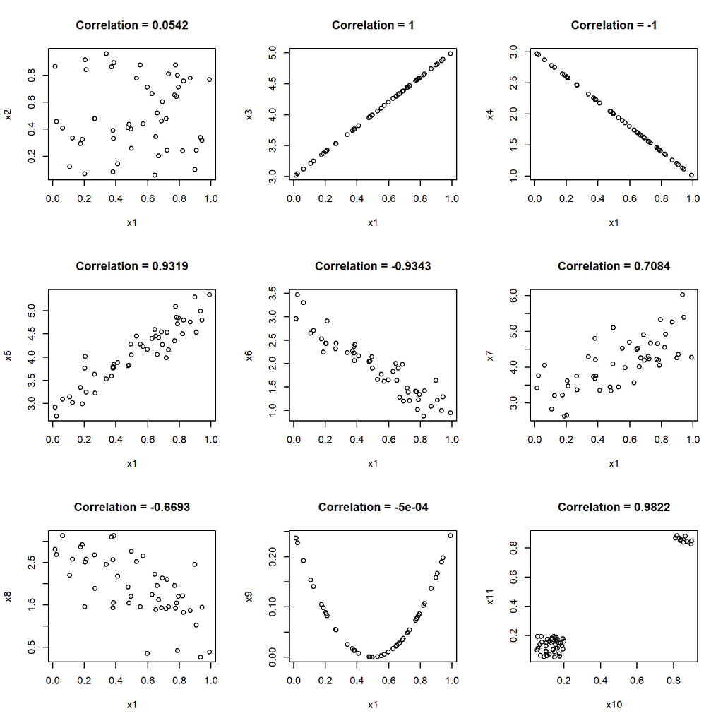

  ```r
  set.seed(1)
  N <- 50
  x1 <- runif(N)
  x2 <- runif(N)
  x3 <- 3 + 2*x1
  x4 <- 3 - 2*x1
  x5 <- x3 + rnorm(N, sd = 0.25)
  x6 <- x4 + rnorm(N, sd = 0.25)
  x7 <- x3 + rnorm(N, sd = 0.5)
  x8 <- x4 + rnorm(N, sd = 0.5)
  x9 <- (x1 - 1/2)^2
  x10 <- c(runif(0.8*N, min = 0.05, max = 0.2),
           runif(0.2*N, min = 0.8, max = 0.9))
  x11 <- c(runif(0.8*N, min = 0.05, max = 0.2),
           runif(0.2*N, min = 0.8, max = 0.9))

  par(mfrow = c(3, 3))
  plot(x1, x2, main = paste("Correlation = ", round(cor(x1, x2), 4), sep = ""))
  plot(x1, x3, main = paste("Correlation = ", round(cor(x1, x3), 4), sep = ""))
  plot(x1, x4, main = paste("Correlation = ", round(cor(x1, x4), 4), sep = ""))
  plot(x1, x5, main = paste("Correlation = ", round(cor(x1, x5), 4), sep = ""))
  plot(x1, x6, main = paste("Correlation = ", round(cor(x1, x6), 4), sep = ""))
  plot(x1, x7, main = paste("Correlation = ", round(cor(x1, x7), 4), sep = ""))
  plot(x1, x8, main = paste("Correlation = ", round(cor(x1, x8), 4), sep = ""))
  plot(x1, x9, main = paste("Correlation = ", round(cor(x1, x9), 4), sep = ""))
  plot(x10, x11, main = paste("Correlation = ", round(cor(x10, x11), 4), sep = ""))
  ```

## Beyond 선형종속성

- 학습데이터 $\{(x_i, y_i), i = 1, 2, ..., N\}$에 대해 순위데이터
  $$r_{i} \,=\, x_1,...,x_n\mbox{에서 }x_i\mbox{의 순위},\quad
  s_{i} \,=\, y_1,...,y_n\mbox{에서 }y_i\mbox{의 순위}$$
  를 구한 뒤, $(r_i, s_i)$ 사이의 상관계수를 구한 것을 **스피어만(Spearman)의 순위상관계수**이라 한다. 이 측도는 변수의 순위 사이의 상관계수를 계산한 것으로 선형 종속성을 넘어 단조적(monotone) 종속성을 측정해준다.
- **켄달(Kendall)의 타우**($\tau$)는 학습데이터에서 두 자료점을 선택해 부합/비부합(concordant/discordant) 여부를 따져서 부합인 쌍의 개수와 비부합인 쌍의 개수의 차이를 이용해 변수 간 연관성을 측정하는 측도이다. $(x_i, y_i)$와 $(x_j,y_j)$에 대해 $(x_i-x_j)(y_i-y_j)>0$가 성립하면 두 쌍이 부합한다고 하고, 그렇지 않으면 비부합이라 한다. 만일 두 변수 사이에 연관성이 낮다면 부합인 쌍의 개수와 비부합인 쌍의 개수가 비슷해져서 그 차이가 0에 가까울 것이고, 연관성이 강하다면 반대일 것이다. 이에 착안해 다음과 같이 상관성의 측도를 정의한다.
  $$\tau = \frac{\mbox{부합인 쌍의 수} - \mbox{비부합인 쌍의
  수}}{\binom{n}{2}}$$
  $\tau$의 값 역시 $+1$과 $-1$사이의 값을 갖게 되는데, 이 값이 양수이면 두 변수가 $x$와 $y$가 양의 상관성이 있음을 의미하고, 음수이면 음의 상관성이 있음을 의미하게 된다.

  ```r
  round(cor(x1, x7, method = "spearman"), 4)
  ```

  ```
  ## [1] 0.7189
  ```

  ```r
  round(cor(x1, x7, method = "kendall"), 4)
  ```

  ```
  ## [1] 0.5167
  ```

  ```r
  round(cor(x10, x11, method = "spearman"), 4)
  ```

  ```
  ## [1] 0.5217
  ```

  ```r
  round(cor(x10, x11, method = "kendall"), 4)
  ```

  ```
  ## [1] 0.3453
  ```

## 예제 데이터 분석

**iris` 데이터**

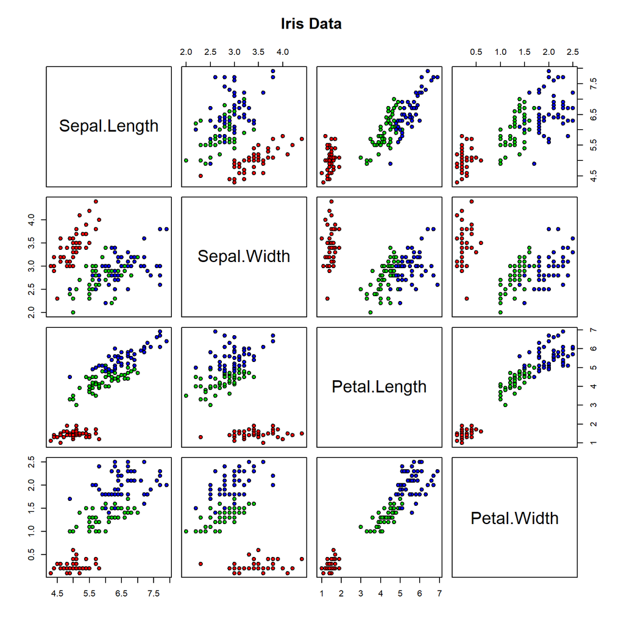

```r
pairs(iris[,1:4],
      main = "Iris Data", pch = 21,
      bg = c("red", "green3", "blue")[unclass(iris$Species)])
```

- 이 데이터에서 `setosa` 품종 데이터만 추출해 변수들 간의 상관성을 분석

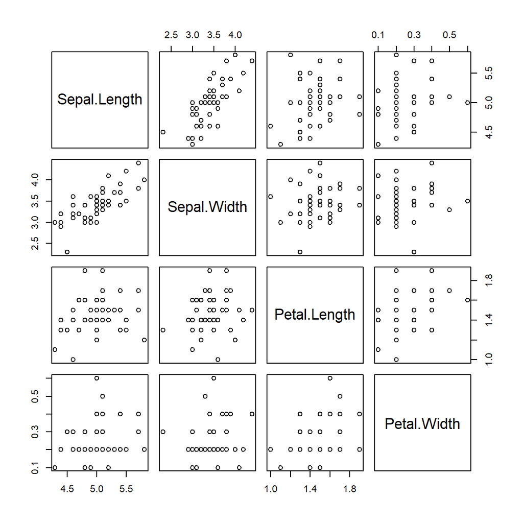

  ```r
  Setosa <- subset(iris, Species == "setosa", select = -Species)
  pairs(Setosa)
  ```

  ```r
  round(cor(Setosa), 4)
  ```

  ```
  ##              Sepal.Length Sepal.Width Petal.Length Petal.Width
  ## Sepal.Length       1.0000      0.7425       0.2672      0.2781
  ## Sepal.Width        0.7425      1.0000       0.1777      0.2328
  ## Petal.Length       0.2672      0.1777       1.0000      0.3316
  ## Petal.Width        0.2781      0.2328       0.3316      1.0000
  ```

  ```r
  round(cor(Setosa, method = "spearman"), 4)
  ```

  ```
  ##              Sepal.Length Sepal.Width Petal.Length Petal.Width
  ## Sepal.Length       1.0000      0.7553       0.2789      0.2995
  ## Sepal.Width        0.7553      1.0000       0.1799      0.2865
  ## Petal.Length       0.2789      0.1799       1.0000      0.2711
  ## Petal.Width        0.2995      0.2865       0.2711      1.0000
  ```

  ```r
  round(cor(Setosa, method = "kendall"), 4)
  ```

  ```
  ##              Sepal.Length Sepal.Width Petal.Length Petal.Width
  ## Sepal.Length       1.0000      0.5973       0.2173      0.2311
  ## Sepal.Width        0.5973      1.0000       0.1426      0.2343
  ## Petal.Length       0.2173      0.1426       1.0000      0.2217
  ## Petal.Width        0.2311      0.2343       0.2217      1.0000
  ```

- `setosa` 품종의 `Sepal.Width`, `Petal.Width` 두 변수 사이의 상관관계가 있는 지 여부를 검정할 수 있음
  $$H_0: \rho = 0\quad \mbox{vs}\quad H_1: \rho > 0$$

  ```r
  with(Setosa, cor.test(Sepal.Width, Petal.Width, alternative = "greater"))
  ```

  ```
  ##
  ##  Pearson's product-moment correlation
  ##
  ## data:  Sepal.Width and Petal.Width
  ## t = 1.6581, df = 48, p-value = 0.05191
  ## alternative hypothesis: true correlation is greater than 0
  ## 95 percent confidence interval:
  ##  -0.00282941  1.00000000
  ## sample estimates:
  ##      cor
  ## 0.232752
  ```

  ```r
  with(Setosa, cor.test(Sepal.Width, Petal.Width, alternative = "greater",
                        method = "spearman", exact = FALSE))
  ```

  ```
  ##
  ##  Spearman's rank correlation rho
  ##
  ## data:  Sepal.Width and Petal.Width
  ## S = 14858, p-value = 0.02183
  ## alternative hypothesis: true rho is greater than 0
  ## sample estimates:
  ##       rho
  ## 0.2865359
  ```

  ```r
  with(Setosa, cor.test(Sepal.Width, Petal.Width, alternative = "greater",
                        method = "kendall", exact = FALSE))
  ```

  ```
  ##
  ##  Kendall's rank correlation tau
  ##
  ## data:  Sepal.Width and Petal.Width
  ## z = 2.0593, p-value = 0.01973
  ## alternative hypothesis: true tau is greater than 0
  ## sample estimates:
  ##       tau
  ## 0.2342674
  ```

# 회귀모형

**회귀분석**

- 변수들 간의 함수적 관계를 밝히려는 통계적 분석 방법
- Francis Galton이 발표한 논문에서 유래
- 기계학습 관점에서 지도학습에 해당

**모형**
$$y = f(\boldsymbol{x}) + \epsilon,\quad \epsilon\sim \bullet (0,
\sigma^2)$$

- $y$: 출력변수(output), 타겟변수(target)
  - 다른 변수 $\boldsymbol x$에 의해 설명되는 변수
  - 관측값에 측정오차를 수반함
  - 통계 용어: 종속변수(dependent variable), 반응변수(response variable)
- $\boldsymbol x$: 입력변수(input), 특징변수(feature), 자질변수(attribute)
  - 변수 $y$에 영향을 주거나 설명하는 변수
  - 보통 관측값에 측정오차가 없음을 가정
  - 통계 용어: 독립변수(independent variable), 설명변수(explanatory variable), 예측변수(predictor), 공변량(covariate)

**회귀분석의 활용**

- 여러 통계적인 분석기법 가운데 가장 널리 쓰임
- 분류 문제도 회귀분석 문제로 볼 수 있음

**유의사항:** 회귀분석은 변수 간의 **연관성(상관관계)**을 규명하는 도구이지, 그 자체로 인과성을 증명해주지는 않음

# 선형회귀

**선형회귀모형**
$$f(\boldsymbol{x}|\boldsymbol{w}) = w_0 + w_1 x_1 + w_2 x_2 + \cdots +
w_d x_d$$

- 실제 회귀함수가 선형이 아닐지라도 선형회귀는 해석 및 활용이 간편하다는 장점을 가지며, 특히 $\boldsymbol{x}$이 다차원 변수인 경우 효과적임

**(훈련)데이터**
$${\cal D} = \{(\boldsymbol{x}_i, y_i)\in\mathbb{R}^d\times\mathbb{R}\,|\,
i = 1, 2, ..., n\}$$

**학습**

- 예측값: $\tilde{y}_i = f(\boldsymbol{x}_i|\boldsymbol{w})$, $i = 1, 2, ..., n$
- 목적함수: training error의 제곱합에 기반한 손실함수 사용. 즉 학습된 가중치가 $\boldsymbol{w} = (w_0, w_1, ..., w_d)^\top$일 때
  $${\cal L}(\boldsymbol{w})
  = \frac{1}{2}\sum_{i=1}^n (y_i - \tilde{y}_i)^2
  = \frac{1}{2}\sum_{i=1}^n \left\{y_i -
  f(\boldsymbol{x}_i|\boldsymbol{w})\right\}^2$$
- 위 손실함수를 최소가 되게 하는 회귀계수의 값을 정하는 것은 Residual Sum of Squares(RSS)를 최소로 만드는 회귀계수의 값을 구하는 최소제곱법(least squares method)과 동일

**Measures of Fit:** $R^2$

- 위 회귀모형에 따르면 개별 $y$값이 서로 달라지게 만드는 요인은 $\boldsymbol{x}$와 $\epsilon$ 두 가지임
- $y$의 변동을 $\epsilon$에 의한 변동과 $\boldsymbol{x}$에 의한 변동(추세에 의한 변동)으로 분해할 수 있음
  - $y$의 변동: ${\sf SST} = \sum_{i=1}^n(y_i-\bar{y})^2$
  - $\epsilon$에 의한 변동: ${\sf RSS} = \sum_{i=1}^n(y_i-\tilde{y}_i)^2$
  - $\boldsymbol{x}$에 의한 변동: ${\sf SST} - {\sf RSS}$
- $R^2$는 $y$의 변동 중 $\boldsymbol{x}$에 의한 변동이 차지하는 상대적 크기를 의미
  $$R^2 = \frac{{\sf SST} - {\sf RSS}}{{\sf SST}} = 1 - \frac{{\sf RSS}}
  {{\sf SST}}$$
  - $R^2$는 항상 $0$과 $1$ 사이의 값을 가짐
  - $R^2$의 값이 $0$에 가까우면 학습된 모형이 설명력이 약함을 의미하고, $1$에 가까우면 학습된 모형이 데이터를 설명하는 힘이 우수하다는 것을 의미

## 예제: 모의실험 자료

  ```r
  gen.data <- function(N, SD, w0, w1)
  {
    x <- runif(N, min = -5, max = 5)
    y <- w0 + w1*x + rnorm(N, sd = SD)

    return(data.frame(x = x, y = y))
  }
  ```

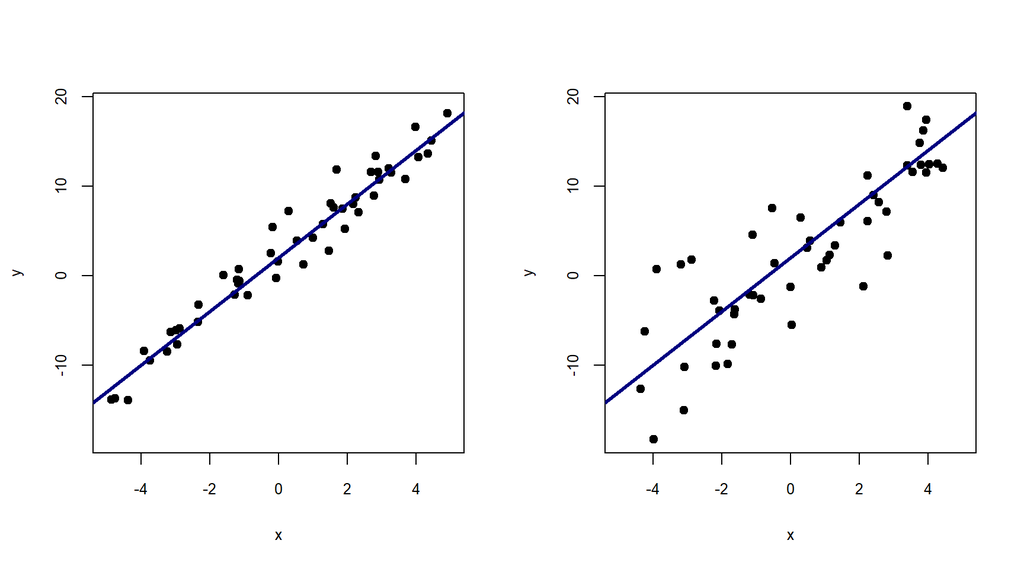

  ```r
  set.seed(1)
  N <- 50; w0 <- 2; w1 <- 3

  dat1 <- gen.data(N = N, SD = 2, w0 = w0, w1 = w1)
  dat2 <- gen.data(N = N, SD = 5, w0 = w0, w1 = w1)

  par(mfrow = c(1, 2))
  ylim <- range(c(dat1$y, dat2$y))
  with(dat1, plot(x, y, pch = 19, xlim = c(-5, 5), ylim = ylim, cex.lab = 0.8, cex.axis = 0.8))
  abline(w0, w1, col = "navy", lwd = 3)
  with(dat2, plot(x, y, pch = 19, xlim = c(-5, 5), ylim = ylim, cex.lab = 0.8, cex.axis = 0.8))
  abline(w0, w1, col = "navy", lwd = 3)
  ```

- 모형 학습:

  ```r
  fit.lm1 <- lm(y ~ x, data = dat1)
  summary(fit.lm1)
  ```

  ```
  ##
  ## Call:
  ## lm(formula = y ~ x, data = dat1)
  ##
  ## Residuals:
  ##     Min      1Q  Median      3Q     Max
  ## -3.8231 -1.1495 -0.2926  1.0207  4.5872
  ##
  ## Coefficients:
  ##             Estimate Std. Error t value Pr(>|t|)
  ## (Intercept)  2.19322    0.26489    8.28 8.34e-11 ***
  ## x            3.01356    0.09758   30.88  < 2e-16 ***
  ## ---
  ## Signif. codes:  0 '***' 0.001 '**' 0.01 '*' 0.05 '.' 0.1 ' ' 1
  ##
  ## Residual standard error: 1.859 on 48 degrees of freedom
  ## Multiple R-squared:  0.9521, Adjusted R-squared:  0.9511
  ## F-statistic: 953.8 on 1 and 48 DF,  p-value: < 2.2e-16
  ```

  ```r
  fit.lm2 <- lm(y ~ x, data = dat2)
  summary(fit.lm2)
  ```

  ```
  ##
  ## Call:
  ## lm(formula = y ~ x, data = dat2)
  ##
  ## Residuals:
  ##     Min      1Q  Median      3Q     Max
  ## -8.4994 -2.4418 -0.3692  2.0265 10.4537
  ##
  ## Coefficients:
  ##             Estimate Std. Error t value Pr(>|t|)
  ## (Intercept)   1.2989     0.6449   2.014   0.0496 *
  ## x             2.8247     0.2415  11.696 1.18e-15 ***
  ## ---
  ## Signif. codes:  0 '***' 0.001 '**' 0.01 '*' 0.05 '.' 0.1 ' ' 1
  ##
  ## Residual standard error: 4.521 on 48 degrees of freedom
  ## Multiple R-squared:  0.7403, Adjusted R-squared:  0.7349
  ## F-statistic: 136.8 on 1 and 48 DF,  p-value: 1.175e-15
  ```

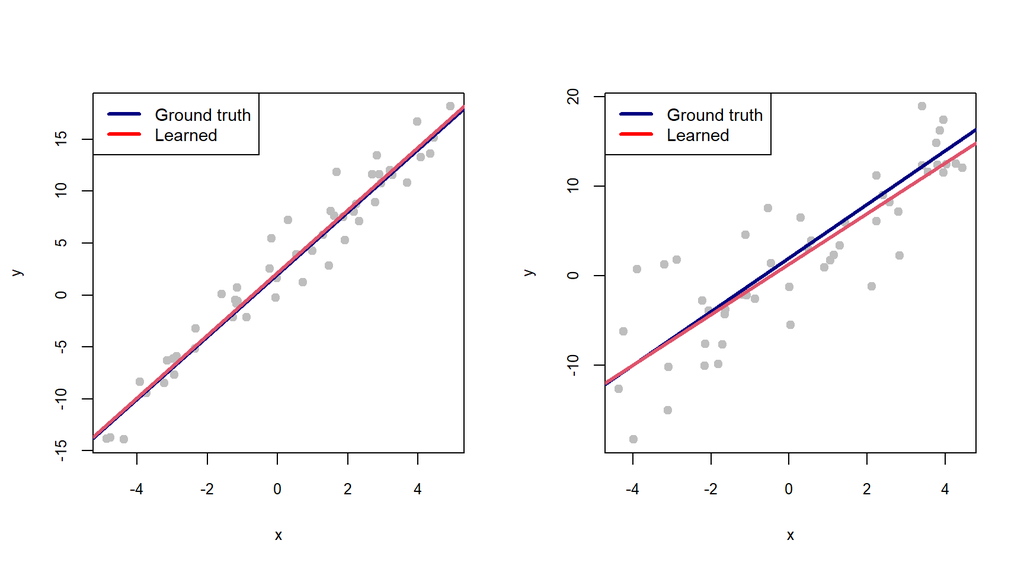

  ```r
  par(mfrow = c(1, 2))
  with(dat1, plot(x, y, pch = 19, col = "gray", cex.lab = 0.8, cex.axis = 0.8))
  abline(w0, w1, col = "navy", lwd = 3)
  abline(coef(fit.lm1), col = 2, lwd = 3)
  legend("topleft", c("Ground truth", "Learned"), col = c("navy", "red"), lwd = c(3, 3), cex = 0.9)
  with(dat2, plot(x, y, pch = 19, col = "gray", cex.lab = 0.8, cex.axis = 0.8))
  abline(w0, w1, col = "navy", lwd = 3)
  abline(coef(fit.lm2), col = 2, lwd = 3)
  legend("topleft", c("Ground truth", "Learned"), col = c("navy", "red"), lwd = c(3, 3), cex = 0.9)
  ```

## 예제 데이터 분석

**Advertising data**

```r
adv <- read.csv(file = "./dat/Advertising.csv")
head(adv)
```

```
##   X    TV Radio Newspaper Sales
## 1 1 230.1  37.8      69.2  22.1
## 2 2  44.5  39.3      45.1  10.4
## 3 3  17.2  45.9      69.3   9.3
## 4 4 151.5  41.3      58.5  18.5
## 5 5 180.8  10.8      58.4  12.9
## 6 6   8.7  48.9      75.0   7.2
```

```r
summary(adv)
```

```
##        X                TV             Radio          Newspaper
##  Min.   :  1.00   Min.   :  0.70   Min.   : 0.000   Min.   :  0.30
##  1st Qu.: 50.75   1st Qu.: 74.38   1st Qu.: 9.975   1st Qu.: 12.75
##  Median :100.50   Median :149.75   Median :22.900   Median : 25.75
##  Mean   :100.50   Mean   :147.04   Mean   :23.264   Mean   : 30.55
##  3rd Qu.:150.25   3rd Qu.:218.82   3rd Qu.:36.525   3rd Qu.: 45.10
##  Max.   :200.00   Max.   :296.40   Max.   :49.600   Max.   :114.00
##      Sales
##  Min.   : 1.60
##  1st Qu.:10.38
##  Median :12.90
##  Mean   :14.02
##  3rd Qu.:17.40
##  Max.   :27.00
```

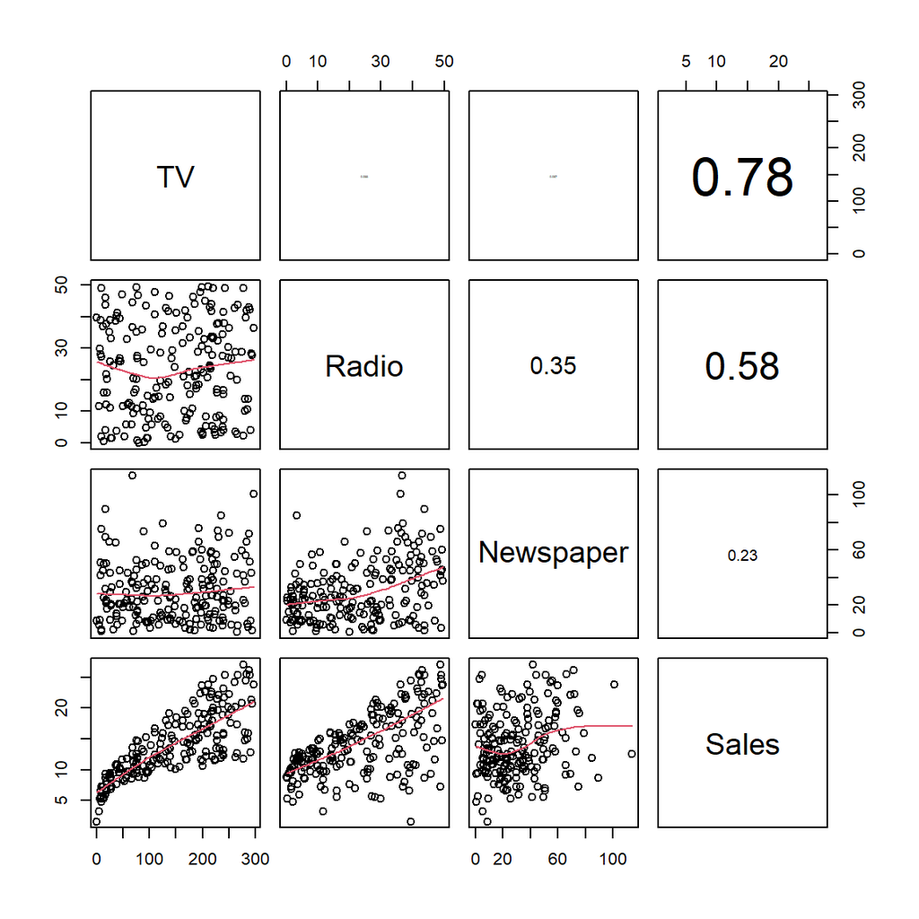

```r
panel.cor <- function(x, y, digits = 2, prefix = "", cex.cor, ...)
{
    par(usr = c(0, 1, 0, 1))
    r <- abs(cor(x, y))
    txt <- format(c(r, 0.123456789), digits = digits)[1]
    txt <- paste0(prefix, txt)
    if(missing(cex.cor)) cex.cor <- 0.8/strwidth(txt)
    text(0.5, 0.5, txt, cex = cex.cor * r)
}

pairs(adv[,-1], lower.panel = panel.smooth, upper.panel = panel.cor)
```

**단순회귀모형**
$${\sf Sales} = w_0 + w_1 \cdot {\sf TV} + \epsilon$$

- 모형 학습

  ```r
  fit.lm <- lm(Sales ~ TV, data = adv)
  summary(fit.lm)
  ```

  ```
  ##
  ## Call:
  ## lm(formula = Sales ~ TV, data = adv)
  ##
  ## Residuals:
  ##     Min      1Q  Median      3Q     Max
  ## -8.3860 -1.9545 -0.1913  2.0671  7.2124
  ##
  ## Coefficients:
  ##             Estimate Std. Error t value Pr(>|t|)
  ## (Intercept) 7.032594   0.457843   15.36   <2e-16 ***
  ## TV          0.047537   0.002691   17.67   <2e-16 ***
  ## ---
  ## Signif. codes:  0 '***' 0.001 '**' 0.01 '*' 0.05 '.' 0.1 ' ' 1
  ##
  ## Residual standard error: 3.259 on 198 degrees of freedom
  ## Multiple R-squared:  0.6119, Adjusted R-squared:  0.6099
  ## F-statistic: 312.1 on 1 and 198 DF,  p-value: < 2.2e-16
  ```

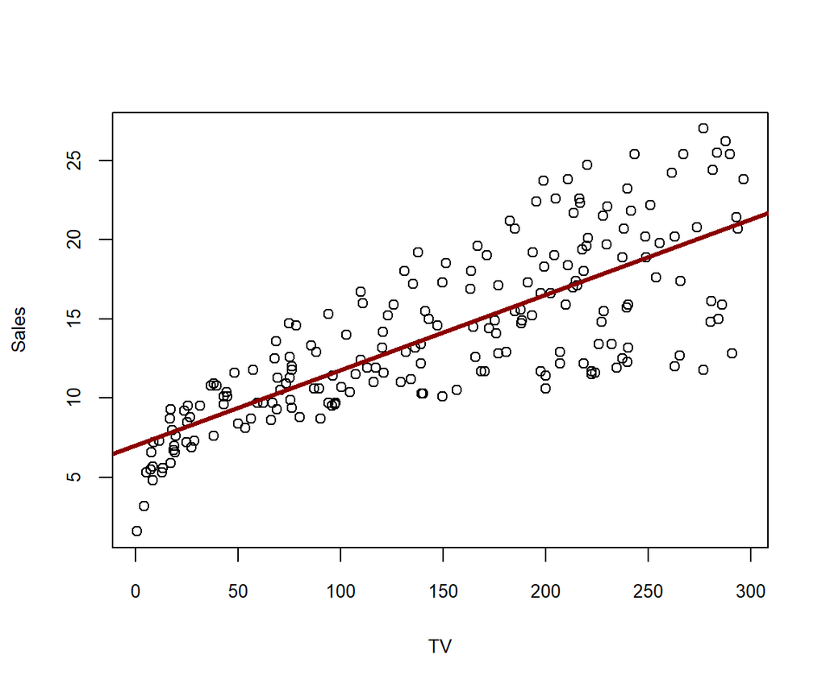

  ```r
  with(adv, plot(TV, Sales, cex.axis = 0.8, cex.lab = 0.8))
  abline(coef(fit.lm), col = "darkred", lwd = 3)
  ```

**다중회귀모형** (설명변수로 `TV` 하나만 쓰는 것보다는 `Radio`, `Newspaper`까지 다 사용하는 것이 좋지 않을까?)
$${\sf Sales} = w_0 + w_1 \cdot {\sf TV} + w_2 \cdot {\sf Radio} + w_3
\cdot {\sf Newspaper} + \epsilon$$

- $w_0$는 절편, $w_j$ ($j=1,2,3$)는 해당 feature 변수의 값이 한 단위 증가하고 나머지의 값은 고정되었을 때, target 변수의 평균 증가량(partial regression coefficients)
- 학습

  ```r
  fit.lm <- lm(Sales ~ TV + Radio + Newspaper, data = adv)
  summary(fit.lm)
  ```

  ```
  ##
  ## Call:
  ## lm(formula = Sales ~ TV + Radio + Newspaper, data = adv)
  ##
  ## Residuals:
  ##     Min      1Q  Median      3Q     Max
  ## -8.8277 -0.8908  0.2418  1.1893  2.8292
  ##
  ## Coefficients:
  ##              Estimate Std. Error t value Pr(>|t|)
  ## (Intercept)  2.938889   0.311908   9.422   <2e-16 ***
  ## TV           0.045765   0.001395  32.809   <2e-16 ***
  ## Radio        0.188530   0.008611  21.893   <2e-16 ***
  ## Newspaper   -0.001037   0.005871  -0.177     0.86
  ## ---
  ## Signif. codes:  0 '***' 0.001 '**' 0.01 '*' 0.05 '.' 0.1 ' ' 1
  ##
  ## Residual standard error: 1.686 on 196 degrees of freedom
  ## Multiple R-squared:  0.8972, Adjusted R-squared:  0.8956
  ## F-statistic: 570.3 on 3 and 196 DF,  p-value: < 2.2e-16
  ```

- 모형 수정
  - `Newspaper`는 유의하지 않은 것으로 나타남
  - `Newspaper`를 제외한 나머지 두 개의 변수만을 포함한 회귀모형

  ```r
  fit.lm <- lm(Sales ~ TV + Radio, data = adv)
  summary(fit.lm)
  ```

  ```
  ##
  ## Call:
  ## lm(formula = Sales ~ TV + Radio, data = adv)
  ##
  ## Residuals:
  ##     Min      1Q  Median      3Q     Max
  ## -8.7977 -0.8752  0.2422  1.1708  2.8328
  ##
  ## Coefficients:
  ##             Estimate Std. Error t value Pr(>|t|)
  ## (Intercept)  2.92110    0.29449   9.919   <2e-16 ***
  ## TV           0.04575    0.00139  32.909   <2e-16 ***
  ## Radio        0.18799    0.00804  23.382   <2e-16 ***
  ## ---
  ## Signif. codes:  0 '***' 0.001 '**' 0.01 '*' 0.05 '.' 0.1 ' ' 1
  ##
  ## Residual standard error: 1.681 on 197 degrees of freedom
  ## Multiple R-squared:  0.8972, Adjusted R-squared:  0.8962
  ## F-statistic: 859.6 on 2 and 197 DF,  p-value: < 2.2e-16
  ```

- 예측 정확도 평가
  - 예측식:
    $${\sf Sales} = 2.9211 + 0.0458 \times {\sf TV} + 0.1880 \times {\sf
    Radio}$$
  - Mean squared error, root MSE, mean absolute error, percentage error:
    $$\begin{eqnarray*}
    & & {\sf MSE} = \frac{1}{n}\sum_{i=1}^n (y_i -
    \tilde{y}_i)^2,\quad {\sf RMSE} = \sqrt{\sf MSE}, \\
    & & {\sf MAE} = \frac{1}{n}\sum_{i=1}^n \left|y_i -
    \tilde{y}_i\right|,\quad
    {\sf PE} = \frac{1}{n}\sum_{i=1}^n \left|\frac{y_i -
    \tilde{y}_i}{y_i}\right|\times 100
    \end{eqnarray*}$$

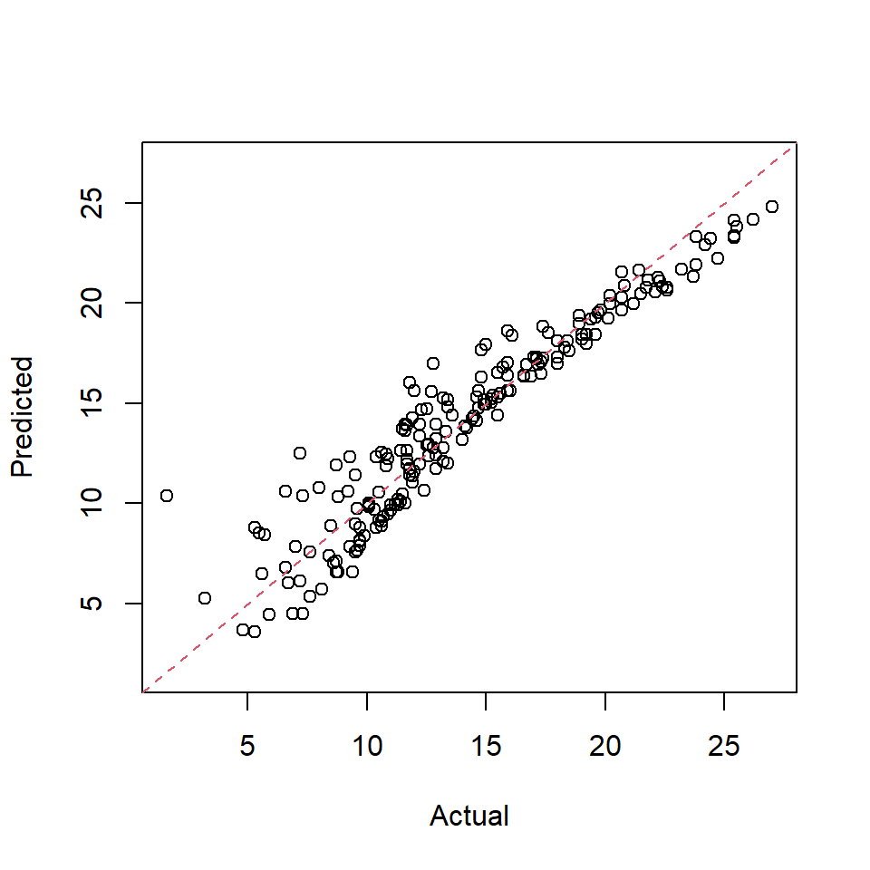

  ```r
  Sales.pred <- predict(fit.lm)
  lbub <- range(c(adv$Sales, Sales.pred))
  plot(adv$Sales, Sales.pred, xlab = "Actual", ylab = "Predicted", xlim = lbub, ylim = lbub)
  abline(0, 1, col = 2, lty = 2)
  ```

  ```r
  pred.error <- adv$Sales - Sales.pred # 예측오차
  mean(pred.error^2)                   # MSE
  ```

  ```
  ## [1] 2.78457
  ```

  ```r
  sqrt(mean(pred.error^2))             # RMSE
  ```

  ```
  ## [1] 1.668703
  ```

  ```r
  mean(abs(pred.error))                # MAE
  ```

  ```
  ## [1] 1.253747
  ```

  ```r
  100*mean(abs(pred.error/Sales.pred)) # PE
  ```

  ```
  ## [1] 11.2578
  ```

- TV 광고비로 100, Radio 광고비로 45를 사용한 경우 Sales 값 예측
  $$\textsf{Sales} = 2.9211 + 0.0458 \times 100 + 0.1880 \times 45$$

  ```r
  newx <- data.frame(TV = 100, Radio = 45)
  predict(fit.lm, newx)
  ```

  ```
  ##        1
  ## 15.95632
  ```

# 변수 선택

- All possible regression
  - 모든 가능한 경우를 고려해 최적 모형을 찾는 방법
  - 비현실적: $2^p$ models with $p$ predictors
- Forward selection (전진선택법) :
  - 절편항만 포함하는 null model로부터 출발해 기여도를 평가(RSS 기준)해 변수를 하나씩 추가해 가는 방법
  - 남은 변수의 기여도가 모두 유의하지 않을 때까지 반복해서 시행
- Backward elimination (후진소거법) :
  - 모든 변수가 들어있는 full model로부터 출발해 기여도가 낮은 변수부터 차례로 제거해 가는 방법
  - 남은 변수가 모두 유의할 때까지 반복해서 시행
- **Stepwise regression** (단계별 선택법) :
  - 변수를 하나씩 추가하면서 새로 들어온 변수로 인해 유의하지 않은 변수는 제거해 가는 방법
  - 새로운 변수의 추가가 없으면 중지
  - 함수 `step()`을 이용하면 간단

  ```r
  fit.lm <- lm(Sales ~ ., data = adv)
  newfit <- step(fit.lm, trace = 1)
  ```

  ```
  ## Start:  AIC=214.71
  ## Sales ~ X + TV + Radio + Newspaper
  ##
  ##             Df Sum of Sq    RSS    AIC
  ## - Newspaper  1      0.13  556.7 212.75
  ## - X          1      0.22  556.8 212.79
  ## <none>                    556.6 214.71
  ## - Radio      1   1354.48 1911.1 459.42
  ## - TV         1   3056.91 3613.5 586.82
  ##
  ## Step:  AIC=212.75
  ## Sales ~ X + TV + Radio
  ##
  ##         Df Sum of Sq    RSS    AIC
  ## - X      1      0.18  556.9 210.82
  ## <none>                556.7 212.75
  ## - Radio  1   1522.57 2079.3 474.29
  ## - TV     1   3060.94 3617.7 585.05
  ##
  ## Step:  AIC=210.82
  ## Sales ~ TV + Radio
  ##
  ##         Df Sum of Sq    RSS    AIC
  ## <none>                556.9 210.82
  ## - Radio  1    1545.6 2102.5 474.52
  ## - TV     1    3061.6 3618.5 583.10
  ```

  ```r
  summary(newfit)
  ```

  ```
  ##
  ## Call:
  ## lm(formula = Sales ~ TV + Radio, data = adv)
  ##
  ## Residuals:
  ##     Min      1Q  Median      3Q     Max
  ## -8.7977 -0.8752  0.2422  1.1708  2.8328
  ##
  ## Coefficients:
  ##             Estimate Std. Error t value Pr(>|t|)
  ## (Intercept)  2.92110    0.29449   9.919   <2e-16 ***
  ## TV           0.04575    0.00139  32.909   <2e-16 ***
  ## Radio        0.18799    0.00804  23.382   <2e-16 ***
  ## ---
  ## Signif. codes:  0 '***' 0.001 '**' 0.01 '*' 0.05 '.' 0.1 ' ' 1
  ##
  ## Residual standard error: 1.681 on 197 degrees of freedom
  ## Multiple R-squared:  0.8972, Adjusted R-squared:  0.8962
  ## F-statistic: 859.6 on 2 and 197 DF,  p-value: < 2.2e-16
  ```

- 최적의 모델을 선택하기 위한 기준
  - $C_p$, AIC, BIC, adjusted-$R^2$, CV 등

# 질적 설명변수

**예제 데이터:** `ISLR` 패키지의 `Credit`

```r
library(ISLR)
summary(Credit)
```

```
##        ID            Income           Limit           Rating
##  Min.   :  1.0   Min.   : 10.35   Min.   :  855   Min.   : 93.0
##  1st Qu.:100.8   1st Qu.: 21.01   1st Qu.: 3088   1st Qu.:247.2
##  Median :200.5   Median : 33.12   Median : 4622   Median :344.0
##  Mean   :200.5   Mean   : 45.22   Mean   : 4736   Mean   :354.9
##  3rd Qu.:300.2   3rd Qu.: 57.47   3rd Qu.: 5873   3rd Qu.:437.2
##  Max.   :400.0   Max.   :186.63   Max.   :13913   Max.   :982.0
##      Cards            Age          Education        Gender    Student
##  Min.   :1.000   Min.   :23.00   Min.   : 5.00    Male :193   No :360
##  1st Qu.:2.000   1st Qu.:41.75   1st Qu.:11.00   Female:207   Yes: 40
##  Median :3.000   Median :56.00   Median :14.00
##  Mean   :2.958   Mean   :55.67   Mean   :13.45
##  3rd Qu.:4.000   3rd Qu.:70.00   3rd Qu.:16.00
##  Max.   :9.000   Max.   :98.00   Max.   :20.00
##  Married              Ethnicity      Balance
##  No :155   African American: 99   Min.   :   0.00
##  Yes:245   Asian           :102   1st Qu.:  68.75
##            Caucasian       :199   Median : 459.50
##                                   Mean   : 520.01
##                                   3rd Qu.: 863.00
##                                   Max.   :1999.00
```

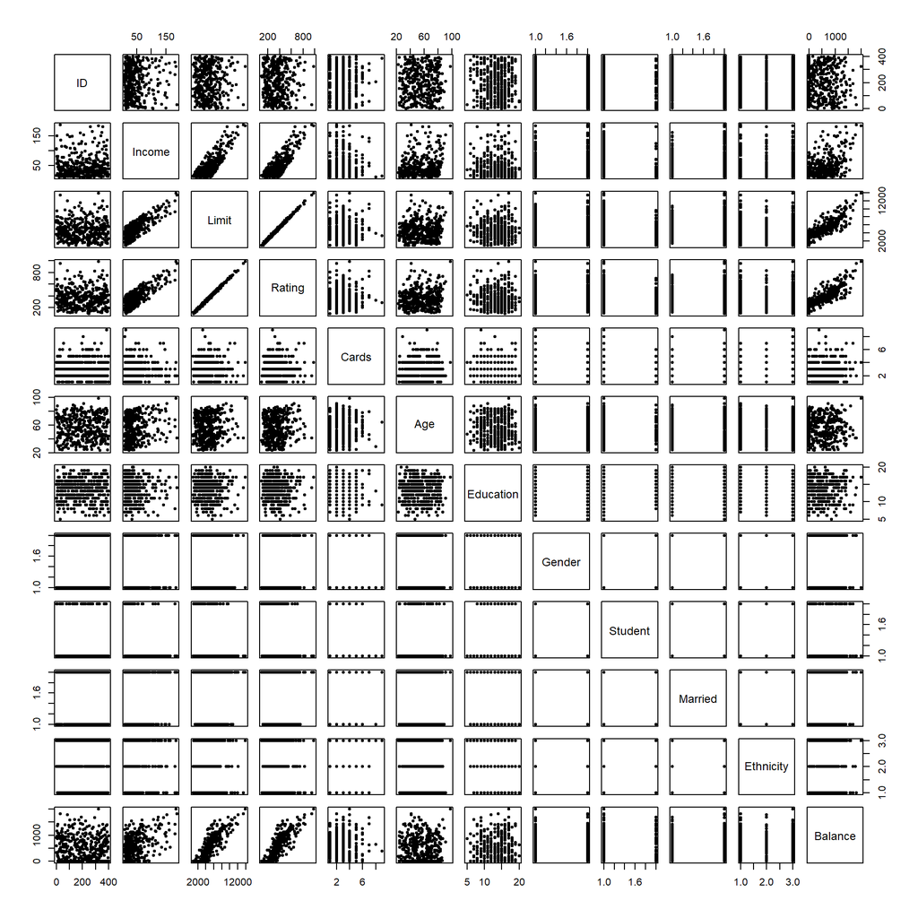

```r
pairs(Credit, pch = 20)
```

## 이항변수

- `Balance`를 target 변수로, `Income`과 `Gender`을 feature 변수로 사용
- 이항변수인 `Gender`를 다음과 같이 인코딩
  $$\textsf{Gender} = \begin{cases} 0 & \quad \text{if }\textsf{Gender =
  male} \\ 1 & \quad \text{if }\textsf{Gender = female}\\ \end{cases}$$
- 모형식
  $$\textsf{Balance} = w_{0} + w_{1} \cdot \textsf{Income} + w_{2} \cdot
  \textsf{Gender} = \begin{cases} w_{0} + w_{1} \cdot \textsf{Income}
  & \quad \text{if }\textsf{Gender = male} \\ w_{0} + w_{1} \cdot
  \textsf{Income} + w_{2} & \quad \text{if }\textsf{Gender = female}\\
  \end{cases}$$
- 학습

  ```r
  fit.lm <- lm(Balance ~ Income + Gender, data = Credit)
  summary(fit.lm)
  ```

  ```
  ##
  ## Call:
  ## lm(formula = Balance ~ Income + Gender, data = Credit)
  ##
  ## Residuals:
  ##     Min      1Q  Median      3Q     Max
  ## -791.23 -351.34  -51.57  328.18 1112.87
  ##
  ## Coefficients:
  ##              Estimate Std. Error t value Pr(>|t|)
  ## (Intercept)  233.7663    39.5322   5.913 7.24e-09 ***
  ## Income         6.0521     0.5799  10.437  < 2e-16 ***
  ## GenderFemale  24.3108    40.8470   0.595    0.552
  ## ---
  ## Signif. codes:  0 '***' 0.001 '**' 0.01 '*' 0.05 '.' 0.1 ' ' 1
  ##
  ## Residual standard error: 408.2 on 397 degrees of freedom
  ## Multiple R-squared:  0.2157, Adjusted R-squared:  0.2117
  ## F-statistic: 54.58 on 2 and 397 DF,  p-value: < 2.2e-16
  ```

- $w_2$의 추정치(`GenderFemale`) 24.3108은 `Income`이 동일한 조건일 때 남성(`Male`) 대비 여성(`Female`)의 `Balance`가 평균적으로 그만큼 높음을 의미.

## 다항변수

- 예를 들어, 3가지 값(Asian, Caucasian, African American)을 갖는 인종(`Ethnicity`) 변수의 경우는 다음 2개의 가변수를 사용하고, 추정하는 회귀식은 아래와 같음
  $$\begin{eqnarray*}
  x_{i1} &=& \begin{cases} 1 & \quad \text{if }\textsf{ Asian}
  \\ 0 & \quad \text{if }\textsf{ Not Asian} \end{cases} \\
  x_{i2} &=& \begin{cases} 1 & \quad \text{if }\textsf{
  Caucasian} \\ 0 & \quad \text{if }\textsf{ Not Caucasian}
  \end{cases}
  \end{eqnarray*}$$
- 모형식
  $${\sf Balance}_i = w_{0} + w_{1} \cdot \textsf{Income} + w_{2}\, x_{i1} +
  w_{3}\, x_{i2} = \begin{cases} w_{0} + w_{1} \cdot \textsf{Income} +
  w_{2} & \quad \text{if }\textsf{Asian} \\ w_{0} + w_{1} \cdot
  \textsf{Income} + w_{3} & \quad \text{if }\textsf{Caucasian}\\
  w_{0} + w_{1} \cdot \textsf{Income} & \quad \text{if
  }\textsf{African American}\\ \end{cases}$$

  ```r
  fit.lm <- lm(Balance ~ Income + Ethnicity, data = Credit)
  summary(fit.lm)
  ```

  ```
  ##
  ## Call:
  ## lm(formula = Balance ~ Income + Ethnicity, data = Credit)
  ##
  ## Residuals:
  ##     Min      1Q  Median      3Q     Max
  ## -806.45 -346.85  -52.38  332.57 1097.57
  ##
  ## Coefficients:
  ##                    Estimate Std. Error t value Pr(>|t|)
  ## (Intercept)        242.4882    49.5674   4.892 1.45e-06 ***
  ## Income               6.0507     0.5813  10.410  < 2e-16 ***
  ## EthnicityAsian       2.4566    57.7230   0.043    0.966
  ## EthnicityCaucasian   6.6188    50.3215   0.132    0.895
  ## ---
  ## Signif. codes:  0 '***' 0.001 '**' 0.01 '*' 0.05 '.' 0.1 ' ' 1
  ##
  ## Residual standard error: 408.9 on 396 degrees of freedom
  ## Multiple R-squared:  0.215,  Adjusted R-squared:  0.2091
  ## F-statistic: 36.16 on 3 and 396 DF,  p-value: < 2.2e-16
  ```

# 다중공선성 문제

**Multicollinearity:** 강한 상관관계가 있는 설명변수들을 모형에 함께 포함시키는 경우 문제를 발생시킴

- 추정된 회귀계수값이 이상하거나 표준오차가 매우 커짐
- 극단적인 경우 모형 학습이 아예 이뤄지지 않을 수 있음

**예제 데이터: Auto**

```r
rmarkdown::paged_table(Auto)
```

|  | mpg | cylinders | displacement | horsepower | weight | acceleration | year | origin | name |
| --- | --- | --- | --- | --- | --- | --- | --- | --- | --- |
| 1 | 18.0 | 8 | 307.0 | 130 | 3504 | 12.0 | 70 | 1 | chevrolet chevelle malibu |
| 2 | 15.0 | 8 | 350.0 | 165 | 3693 | 11.5 | 70 | 1 | buick skylark 320 |
| 3 | 18.0 | 8 | 318.0 | 150 | 3436 | 11.0 | 70 | 1 | plymouth satellite |
| 4 | 16.0 | 8 | 304.0 | 150 | 3433 | 12.0 | 70 | 1 | amc rebel sst |
| 5 | 17.0 | 8 | 302.0 | 140 | 3449 | 10.5 | 70 | 1 | ford torino |
| 6 | 15.0 | 8 | 429.0 | 198 | 4341 | 10.0 | 70 | 1 | ford galaxie 500 |
| 7 | 14.0 | 8 | 454.0 | 220 | 4354 | 9.0 | 70 | 1 | chevrolet impala |
| 8 | 14.0 | 8 | 440.0 | 215 | 4312 | 8.5 | 70 | 1 | plymouth fury iii |
| 9 | 14.0 | 8 | 455.0 | 225 | 4425 | 10.0 | 70 | 1 | pontiac catalina |
| 10 | 15.0 | 8 | 390.0 | 190 | 3850 | 8.5 | 70 | 1 | amc ambassador dpl |

[output cut: 382 more lines]

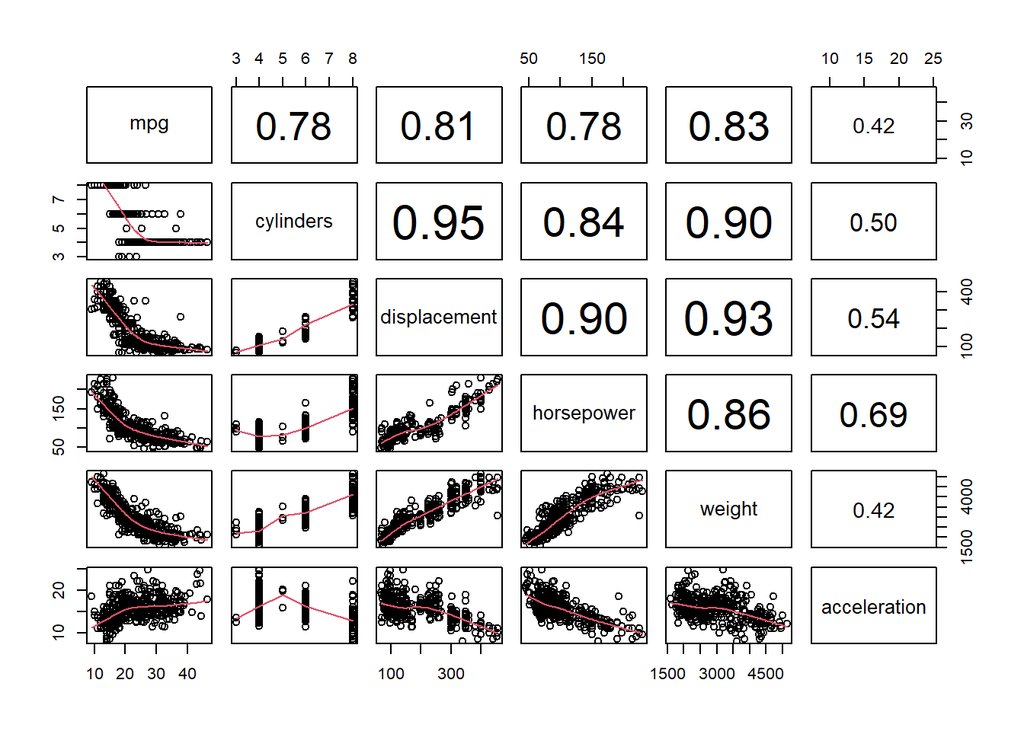

```r
pairs(Auto[,1:6], lower.panel = panel.smooth, upper.panel = panel.cor)
```

```r
fit.lm <- lm(mpg ~ displacement + horsepower + weight + acceleration, data = Auto)
summary(fit.lm)
```

```
##
## Call:
## lm(formula = mpg ~ displacement + horsepower + weight + acceleration,
##     data = Auto)
##
## Residuals:
##     Min      1Q  Median      3Q     Max
## -11.378  -2.793  -0.333   2.193  16.256
##
## Coefficients:
##                Estimate Std. Error t value Pr(>|t|)
## (Intercept)  45.2511397  2.4560447  18.424  < 2e-16 ***
## displacement -0.0060009  0.0067093  -0.894  0.37166
## horsepower   -0.0436077  0.0165735  -2.631  0.00885 **
## weight       -0.0052805  0.0008109  -6.512  2.3e-10 ***
## acceleration -0.0231480  0.1256012  -0.184  0.85388
## ---
## Signif. codes:  0 '***' 0.001 '**' 0.01 '*' 0.05 '.' 0.1 ' ' 1
##
## Residual standard error: 4.247 on 387 degrees of freedom
## Multiple R-squared:  0.707,  Adjusted R-squared:  0.704
## F-statistic: 233.4 on 4 and 387 DF,  p-value: < 2.2e-16
```

**분산팽창계수 VIF**

- Variance inflation factor (VIF)
  $$\textsf{VIF}(j) = \frac{1}{1 - R_{j | -j}^2}$$
  단, $R_{j| -j}^2$는 $x_j$를 target 변수로 하고 나머지 변수들을 feature 변수로 해서 적합시킨 선형회귀모형의 $R^2$
- 보통 VIF값이 10 이상인 설명변수가 있으면 다중공선성 문제가 있다고 봄

  ```r
  library(car)
  vif(fit.lm)
  ```

  ```
  ## displacement   horsepower       weight acceleration
  ##    10.686922     8.823022    10.284456     2.603255
  ```

- Remedy 1: VIF에서 탐지된 변수를 제거

  ```r
  fit.lm1 <- lm(mpg ~ horsepower + acceleration, data = Auto)
  summary(fit.lm1)
  ```

  ```
  ##
  ## Call:
  ## lm(formula = mpg ~ horsepower + acceleration, data = Auto)
  ##
  ## Residuals:
  ##      Min       1Q   Median       3Q      Max
  ## -12.1352  -3.2153  -0.6908   2.6769  17.1734
  ##
  ## Coefficients:
  ##               Estimate Std. Error t value Pr(>|t|)
  ## (Intercept)  52.559325   2.587045  20.316  < 2e-16 ***
  ## horsepower   -0.187966   0.008627 -21.788  < 2e-16 ***
  ## acceleration -0.609772   0.120361  -5.066 6.28e-07 ***
  ## ---
  ## Signif. codes:  0 '***' 0.001 '**' 0.01 '*' 0.05 '.' 0.1 ' ' 1
  ##
  ## Residual standard error: 4.758 on 389 degrees of freedom
  ## Multiple R-squared:  0.6303, Adjusted R-squared:  0.6284
  ## F-statistic: 331.7 on 2 and 389 DF,  p-value: < 2.2e-16
  ```

- Remedy 2: Stewise 변수 선택

  ```r
  fit.lm2 <- step(fit.lm, trace = 0)
  summary(fit.lm2)
  ```

  ```
  ##
  ## Call:
  ## lm(formula = mpg ~ horsepower + weight, data = Auto)
  ##
  ## Residuals:
  ##      Min       1Q   Median       3Q      Max
  ## -11.0762  -2.7340  -0.3312   2.1752  16.2601
  ##
  ## Coefficients:
  ##               Estimate Std. Error t value Pr(>|t|)
  ## (Intercept) 45.6402108  0.7931958  57.540  < 2e-16 ***
  ## horsepower  -0.0473029  0.0110851  -4.267 2.49e-05 ***
  ## weight      -0.0057942  0.0005023 -11.535  < 2e-16 ***
  ## ---
  ## Signif. codes:  0 '***' 0.001 '**' 0.01 '*' 0.05 '.' 0.1 ' ' 1
  ##
  ## Residual standard error: 4.24 on 389 degrees of freedom
  ## Multiple R-squared:  0.7064, Adjusted R-squared:  0.7049
  ## F-statistic: 467.9 on 2 and 389 DF,  p-value: < 2.2e-16
  ```

- Remedy 3: 주성분회귀

  ```r
  pc <- princomp(Auto[,3:6], scores = TRUE)
  summary(pc)
  ```

  ```
  ## Importance of components:
  ##                             Comp.1       Comp.2       Comp.3       Comp.4
  ## Standard deviation     854.5642553 38.845504971 1.612657e+01 1.701645e+00
  ## Proportion of Variance   0.9975795  0.002061292 3.552565e-04 3.955449e-06
  ## Cumulative Proportion    0.9975795  0.999640788 9.999960e-01 1.000000e+00
  ```

  ```r
  fit.lm3 <- lm(Auto$mpg ~ pc$scores[,1])
  summary(fit.lm3)
  ```

  ```
  ##
  ## Call:
  ## lm(formula = Auto$mpg ~ pc$scores[, 1])
  ##
  ## Residuals:
  ##      Min       1Q   Median       3Q      Max
  ## -11.9945  -2.7754  -0.3577   2.1331  16.5064
  ##
  ## Coefficients:
  ##                  Estimate Std. Error t value Pr(>|t|)
  ## (Intercept)    23.4459184  0.2185435   107.3   <2e-16 ***
  ## pc$scores[, 1] -0.0075959  0.0002557   -29.7   <2e-16 ***
  ## ---
  ## Signif. codes:  0 '***' 0.001 '**' 0.01 '*' 0.05 '.' 0.1 ' ' 1
  ##
  ## Residual standard error: 4.327 on 390 degrees of freedom
  ## Multiple R-squared:  0.6934, Adjusted R-squared:  0.6927
  ## F-statistic: 882.2 on 1 and 390 DF,  p-value: < 2.2e-16
  ```

# 다항회귀

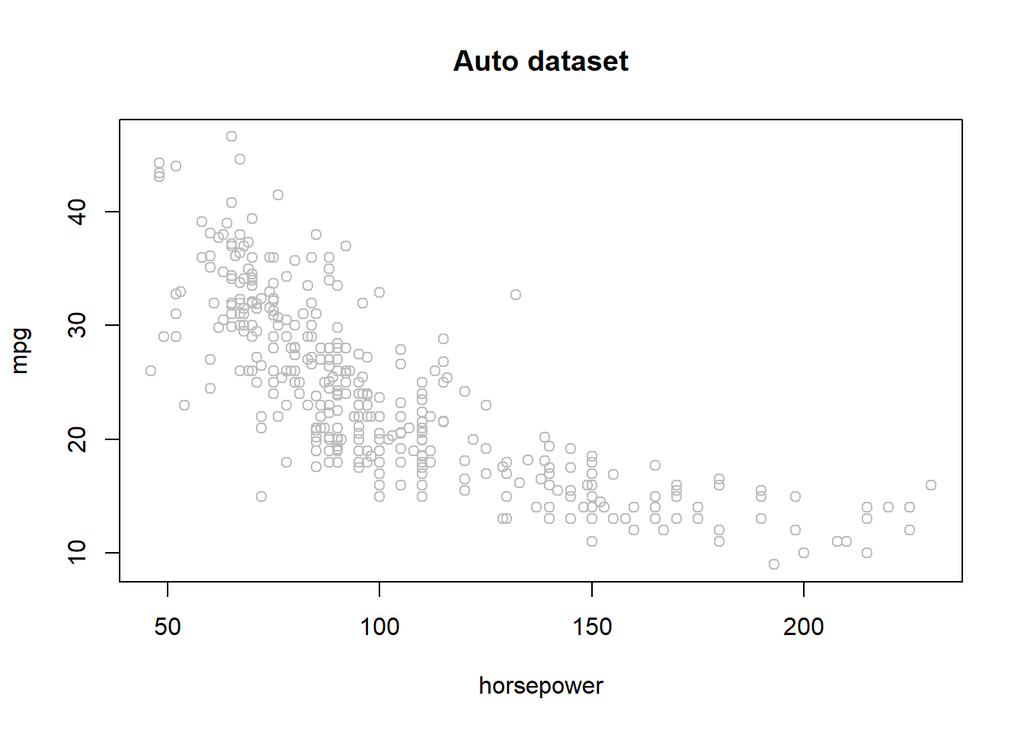

```r
with(Auto, plot(horsepower, mpg, col = "gray", main = "Auto dataset"))
```

회귀함수로 일차식을 사용하는 것이 적절치 않은 경우 **다항식**을 사용:
$$f({\sf horsepower}) = w_0 + w_1 \times {\sf horsepower} + \cdots + w_d
\times {\sf horsepower}^d$$

```r
fit.lm1 <- lm(mpg ~ horsepower, data = Auto)
fit.lm2 <- lm(mpg ~ horsepower + I(horsepower^2), data = Auto)
fit.lm3 <- lm(mpg ~ poly(horsepower, 3), data = Auto)
fit.lm4 <- lm(mpg ~ poly(horsepower, 15), data = Auto)
```

```r
x <- seq(from = min(Auto$horsepower), to = max(Auto$horsepower), by = 0.0025)
pred1 <- predict(fit.lm1, newdata = data.frame(horsepower = x))
pred2 <- predict(fit.lm2, newdata = data.frame(horsepower = x, x^2))
pred3 <- predict(fit.lm3, newdata = data.frame(horsepower = x))
pred4 <- predict(fit.lm4, newdata = data.frame(horsepower = x))
```

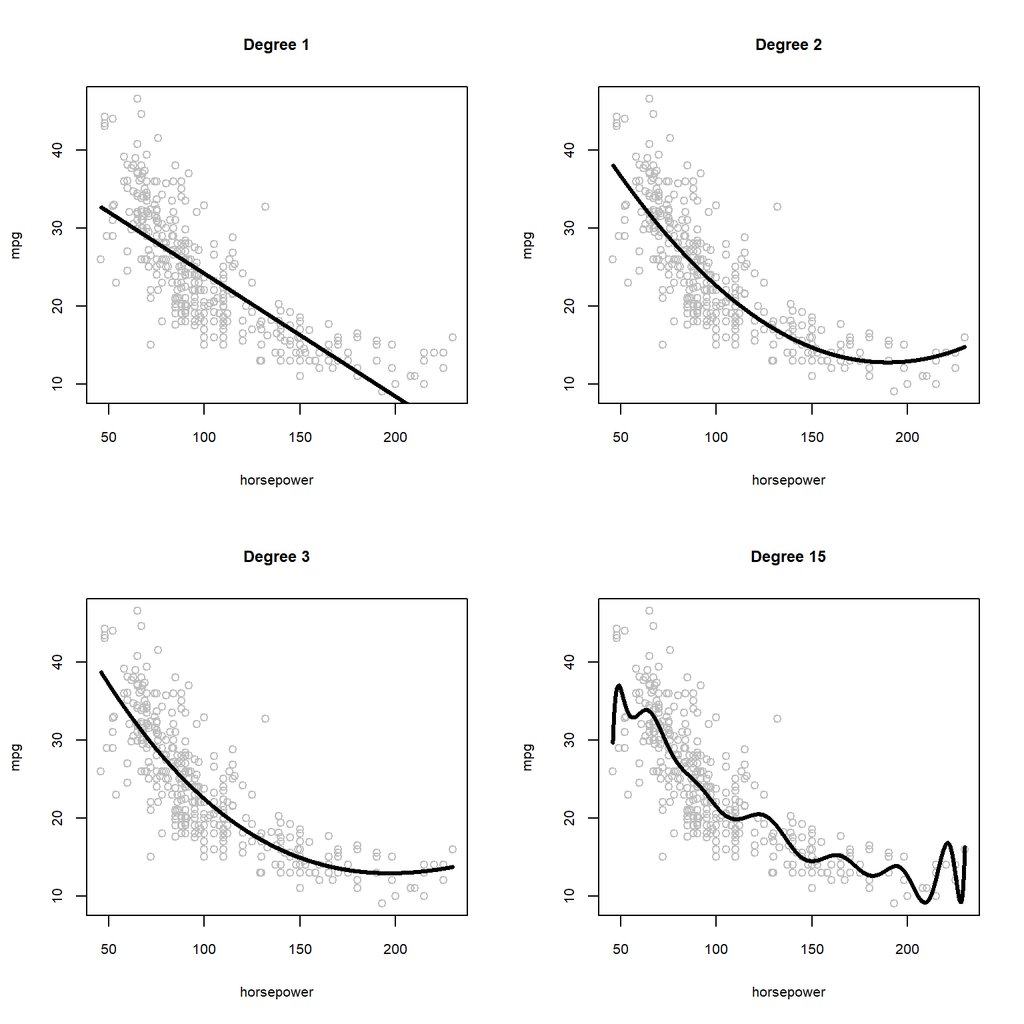

```r
par(mfrow = c(2, 2))
with(Auto, plot(horsepower, mpg, col = "gray", main = "Degree 1",
                cex.axis = 0.8, cex.lab = 0.8, cex.main = 0.9))
lines(x, pred1, lwd = 3)
with(Auto, plot(horsepower, mpg, col = "gray", main = "Degree 2",
                cex.axis = 0.8, cex.lab = 0.8, cex.main = 0.9))
lines(x, pred2, lwd = 3)
with(Auto, plot(horsepower, mpg, col = "gray", main = "Degree 3",
                cex.axis = 0.8, cex.lab = 0.8, cex.main = 0.9))
lines(x, pred3, lwd = 3)
with(Auto, plot(horsepower, mpg, col = "gray", main = "Degree 15",
                cex.axis = 0.8, cex.lab = 0.8, cex.main = 0.9))
lines(x, pred4, lwd = 3)
```

# 교호작용

## 양적변수 사이의 교호작용

- $x_1$의 증가로 인한 $y$의 (증가 혹은 감소와 같은) 효과가 $x_2$값의 수준에 따라 달라질 때, $x_1$와 $x_2$ 사이에 **interaction**이 존재한다고 함
- 예제: Advertising 데이터
  - `TV`와 `Radio`의 광고는 모두 판매량을 증가시킴
    $$\textsf{Sales} = w_{0} + w_{1} \times \textsf{TV} + w_{2} \times
    \textsf{Radio} + w_{12} \times \textsf{TV} \times \textsf{Radio}$$

  ```r
  fit.lm <- lm(Sales ~ TV + Radio, data = adv)
  summary(fit.lm)
  ```

  ```
  ##
  ## Call:
  ## lm(formula = Sales ~ TV + Radio, data = adv)
  ##
  ## Residuals:
  ##     Min      1Q  Median      3Q     Max
  ## -8.7977 -0.8752  0.2422  1.1708  2.8328
  ##
  ## Coefficients:
  ##             Estimate Std. Error t value Pr(>|t|)
  ## (Intercept)  2.92110    0.29449   9.919   <2e-16 ***
  ## TV           0.04575    0.00139  32.909   <2e-16 ***
  ## Radio        0.18799    0.00804  23.382   <2e-16 ***
  ## ---
  ## Signif. codes:  0 '***' 0.001 '**' 0.01 '*' 0.05 '.' 0.1 ' ' 1
  ##
  ## Residual standard error: 1.681 on 197 degrees of freedom
  ## Multiple R-squared:  0.8972, Adjusted R-squared:  0.8962
  ## F-statistic: 859.6 on 2 and 197 DF,  p-value: < 2.2e-16
  ```

  - 두 가지 미디어 광고에 돈을 사용하는 것이 한 가지 광고에만 사용하는 것보다 판매량을 더 많이 증가시킴(**조절효과 moderation**)
    $$\begin{eqnarray*}
    & & \textsf{Sales} = w_{0} + w_{1} \times \textsf{TV} + w_{2}
    \times \textsf{Radio} + w_{12} \times \textsf{TV} \times \textsf{Radio}
    \\
    & & \Leftrightarrow\quad\textsf{Sales} = w_{0} + (w_{1} +
    w_{12} \times \textsf{Radio}) \times \textsf{TV} + w_{2} \times
    \textsf{Radio}\\
    & & \Leftrightarrow\quad\textsf{Sales} = w_{0} + (w_{2} +
    w_{12} \times \textsf{TV}) \times \textsf{Radio} + w_{2} \times
    \textsf{TV}
    \end{eqnarray*}$$

  ```r
  fit.lm <- lm(Sales ~ TV * Radio, data = adv)
  summary(fit.lm)
  ```

  ```
  ##
  ## Call:
  ## lm(formula = Sales ~ TV * Radio, data = adv)
  ##
  ## Residuals:
  ##     Min      1Q  Median      3Q     Max
  ## -6.3366 -0.4028  0.1831  0.5948  1.5246
  ##
  ## Coefficients:
  ##              Estimate Std. Error t value Pr(>|t|)
  ## (Intercept) 6.750e+00  2.479e-01  27.233   <2e-16 ***
  ## TV          1.910e-02  1.504e-03  12.699   <2e-16 ***
  ## Radio       2.886e-02  8.905e-03   3.241   0.0014 **
  ## TV:Radio    1.086e-03  5.242e-05  20.727   <2e-16 ***
  ## ---
  ## Signif. codes:  0 '***' 0.001 '**' 0.01 '*' 0.05 '.' 0.1 ' ' 1
  ##
  ## Residual standard error: 0.9435 on 196 degrees of freedom
  ## Multiple R-squared:  0.9678, Adjusted R-squared:  0.9673
  ## F-statistic:  1963 on 3 and 196 DF,  p-value: < 2.2e-16
  ```

*Note*: *Hierarchical principle states that if we include an interaction in a model, we should also include the main effects, even if the p-values associated with their coefficients are not significant.*

## 질적변수와의 교호작용

**예제 데이터: `ISLR::Credit`**
$$\textsf{Balance}
= w_{0} + w_{1} \times \textsf{Income} + w_{2} \times \textsf{Student}$$
vs.
$$\begin{eqnarray*}
\textsf{Balance}
&=& w_{0} + w_{1} \times \textsf{Income} + w_{2} \times
\textsf{Student} + w_{12}\times \textsf{Income}\times\textsf{Student} \\
&=& \begin{cases} w_{0} + w_{1} \times \textsf{Income} &
\text{if }\,\textsf{Non-Student} \\ (w_{0} + w_{2}) + (w_{1} +
w_{12})\times\textsf{Income} & \text{if }\,\textsf{Student}\\
\end{cases}
\end{eqnarray*}$$

- 산점도

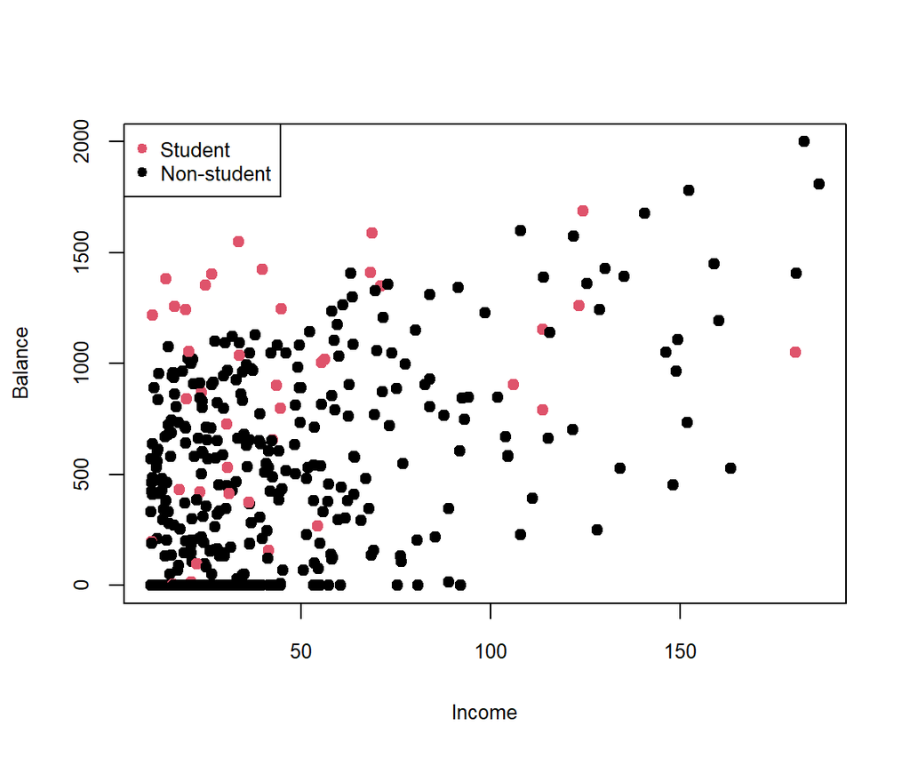

  ```r
  with(Credit, plot(Balance ~ Income, col = Student, pch = 19, cex.lab = 0.8, cex.axis = 0.8))
  legend("topleft", c("Student", "Non-student"), col = c(2, 1), pch = c(19, 19), cex = 0.8)
  ```

- 교호작용이 없는 모형

  ```r
  fit.lm1 <- lm(Balance ~ Income + Student, data = Credit)
  summary(fit.lm1)
  ```

  ```
  ##
  ## Call:
  ## lm(formula = Balance ~ Income + Student, data = Credit)
  ##
  ## Residuals:
  ##     Min      1Q  Median      3Q     Max
  ## -762.37 -331.38  -45.04  323.60  818.28
  ##
  ## Coefficients:
  ##             Estimate Std. Error t value Pr(>|t|)
  ## (Intercept) 211.1430    32.4572   6.505 2.34e-10 ***
  ## Income        5.9843     0.5566  10.751  < 2e-16 ***
  ## StudentYes  382.6705    65.3108   5.859 9.78e-09 ***
  ## ---
  ## Signif. codes:  0 '***' 0.001 '**' 0.01 '*' 0.05 '.' 0.1 ' ' 1
  ##
  ## Residual standard error: 391.8 on 397 degrees of freedom
  ## Multiple R-squared:  0.2775, Adjusted R-squared:  0.2738
  ## F-statistic: 76.22 on 2 and 397 DF,  p-value: < 2.2e-16
  ```

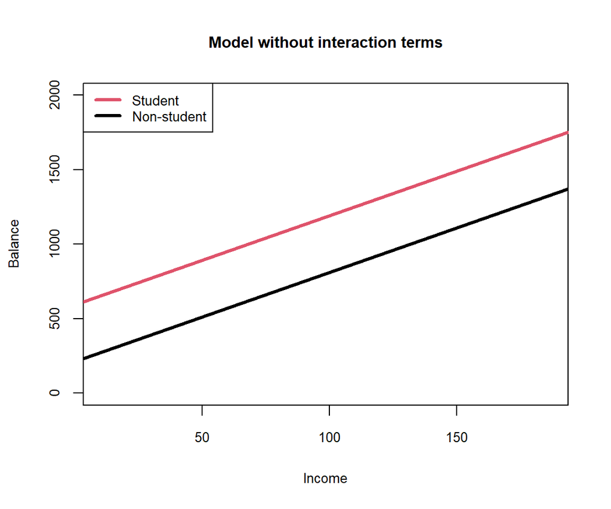

  ```r
  with(Credit, plot(Income, Balance, type = "n",
                    main = "Model without interaction terms",
                    cex.lab = 0.8, cex.axis = 0.8, cex.main = 0.9))
  w <- coef(fit.lm1)
  abline(w[1], w[2], lwd = 3)
  abline(w[1] + w[3], w[2], lwd = 3, col = 2)
  legend("topleft", c("Student", "Non-student"), col = c(2, 1), lwd = c(3, 3), cex = 0.8)
  ```

- 교호작용이 있는 모형

  ```r
  fit.lm2 <- lm(Balance ~ Income * Student, data = Credit)
  summary(fit.lm2)
  ```

  ```
  ##
  ## Call:
  ## lm(formula = Balance ~ Income * Student, data = Credit)
  ##
  ## Residuals:
  ##     Min      1Q  Median      3Q     Max
  ## -773.39 -325.70  -41.13  321.65  814.04
  ##
  ## Coefficients:
  ##                   Estimate Std. Error t value Pr(>|t|)
  ## (Intercept)       200.6232    33.6984   5.953 5.79e-09 ***
  ## Income              6.2182     0.5921  10.502  < 2e-16 ***
  ## StudentYes        476.6758   104.3512   4.568 6.59e-06 ***
  ## Income:StudentYes  -1.9992     1.7313  -1.155    0.249
  ## ---
  ## Signif. codes:  0 '***' 0.001 '**' 0.01 '*' 0.05 '.' 0.1 ' ' 1
  ##
  ## Residual standard error: 391.6 on 396 degrees of freedom
  ## Multiple R-squared:  0.2799, Adjusted R-squared:  0.2744
  ## F-statistic:  51.3 on 3 and 396 DF,  p-value: < 2.2e-16
  ```

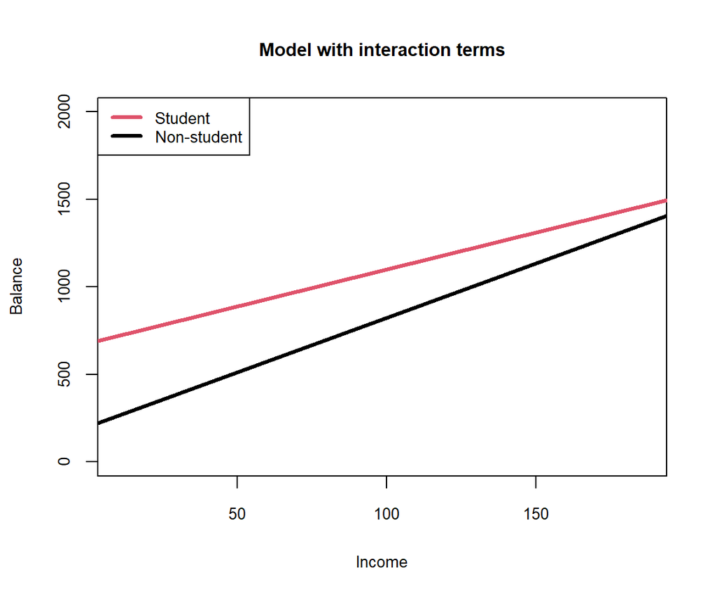

  ```r
  with(Credit, plot(Income, Balance, type = "n",
                    main = "Model with interaction terms",
                    cex.lab = 0.8, cex.axis = 0.8, cex.main = 0.9))
  w <- coef(fit.lm2)
  abline(w[1], w[2], lwd = 3)
  abline(w[1] + w[3], w[2] + w[4], lwd = 3, col = 2)
  legend("topleft", c("Student", "Non-student"), col = c(2, 1), lwd = c(3, 3), cex = 0.8)
  ```